# Abbildungen für Version 4.0

Links die bisherige Abbildung, rechts der Vorschlag. Alle Bilder liegen zusätzlich als bearbeitbare draw.io-Dateien vor.

## Teil 1: Überarbeitete Abbildungen

Kap 4**if.png**

Nur neu gezeichnet: dreifache Auflösung, sonst unverändert.

**bisher**

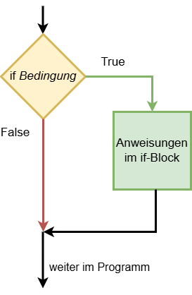

**neu**

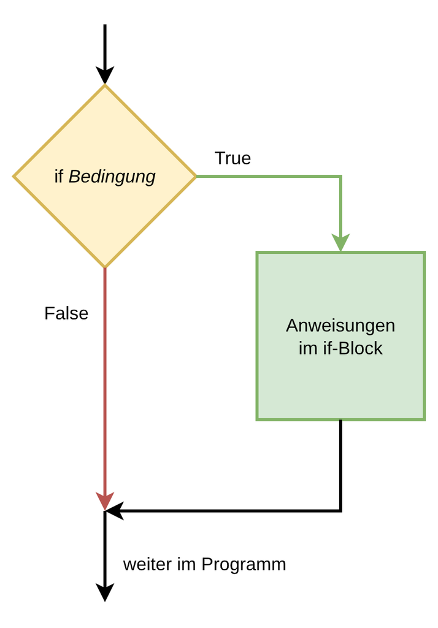

Kap 4**ifelse.png**

Struktur wie bisher (else-Oval unter dem if, else-Block eingerückt unter dem if-Block, analog zur Code-Syntax); nur neu gezeichnet in dreifacher Auflösung.

**bisher**

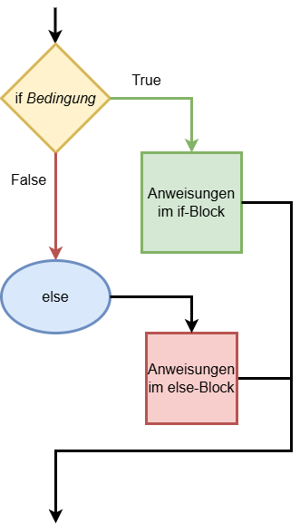

**neu**

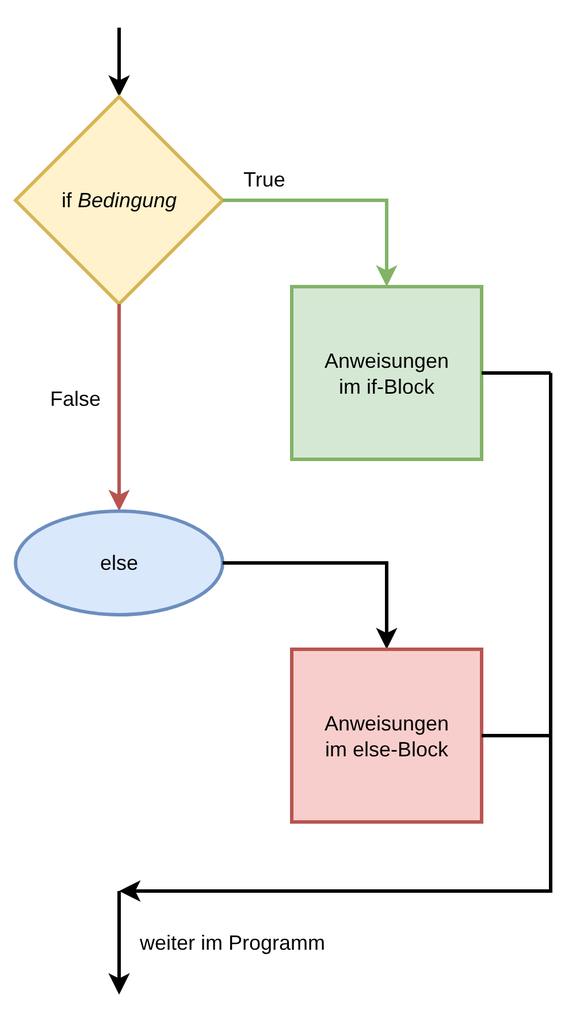

Kap 4**elif.png**

Struktur wie bisher (else-Oval in der Spalte von if/elif, else-Block eingerückt); nur neu gezeichnet in dreifacher Auflösung.

**bisher**

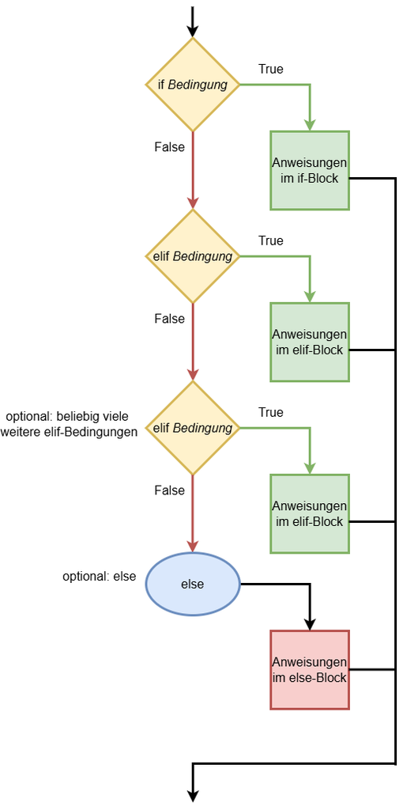

**neu**

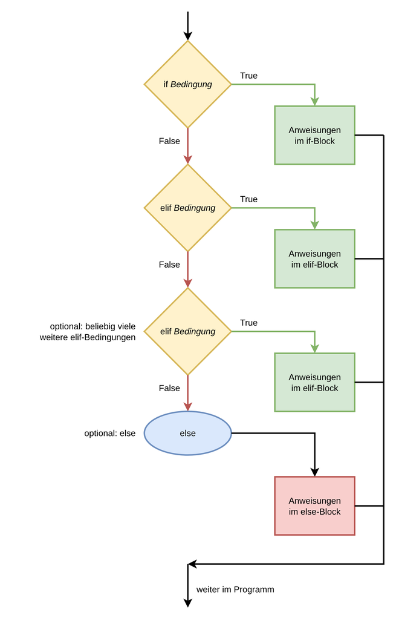

Kap 4**while.png**

Nur neu gezeichnet: dreifache Auflösung.

**bisher**

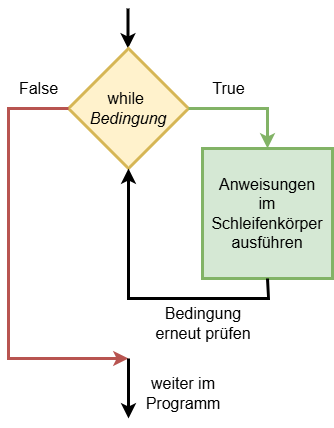

**neu**

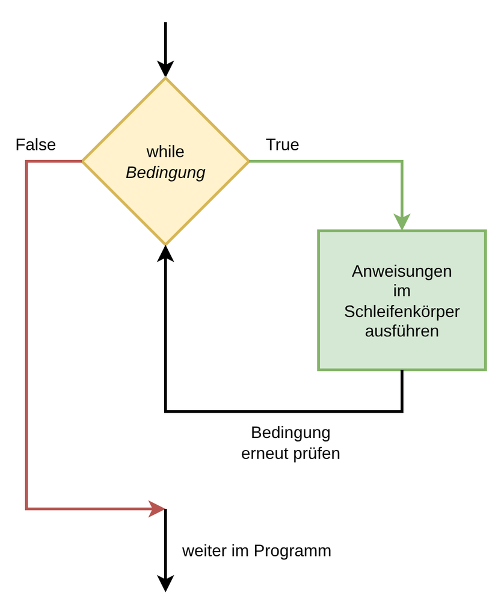

Kap 4**for.png**

Nur neu gezeichnet: dreifache Auflösung.

**bisher**

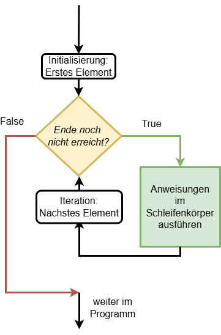

**neu**

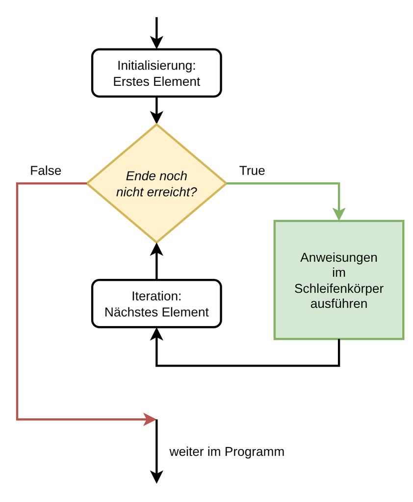

Kap 3**memory_model.png**

Einheitliche Schriftgröße der Adressen (0x00 war kleiner), höhere Auflösung.

**bisher**

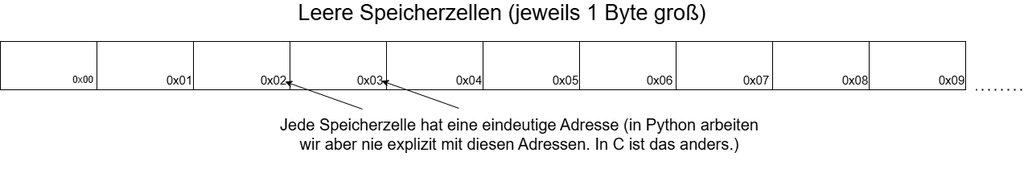

**neu**

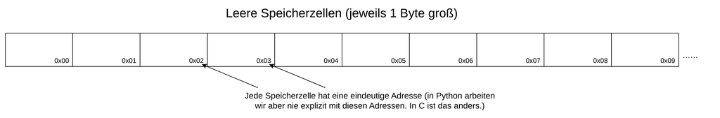

Kap 3**memory_instances.png**

„Variablen“ berührt den Kasten nicht mehr, Kasten kompakter.

**bisher**

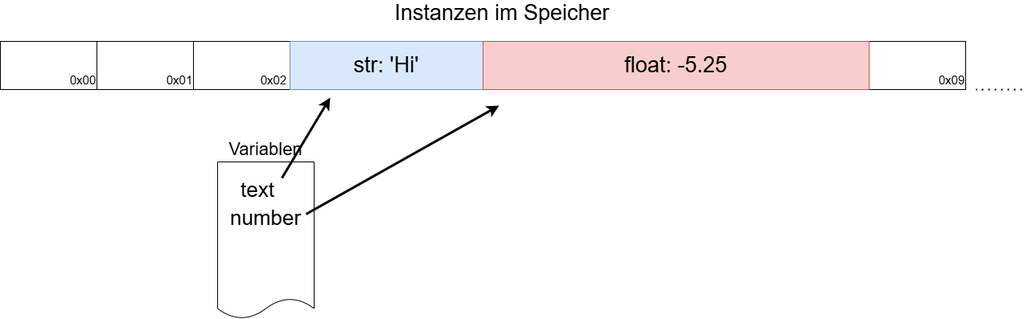

**neu**

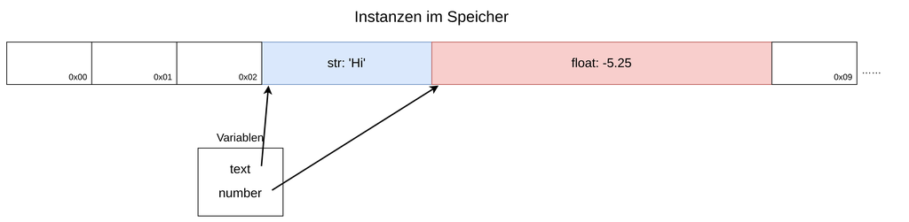

Kap 3**memory_binary.png**

Bits des Floats in Bytes gruppiert (lesbarer). Vorschlag für die Bildunterschrift: „… (Float wie im Rechenbeispiel vereinfacht mit 32 Bit; Python verwendet 64 Bit)“.

**bisher**

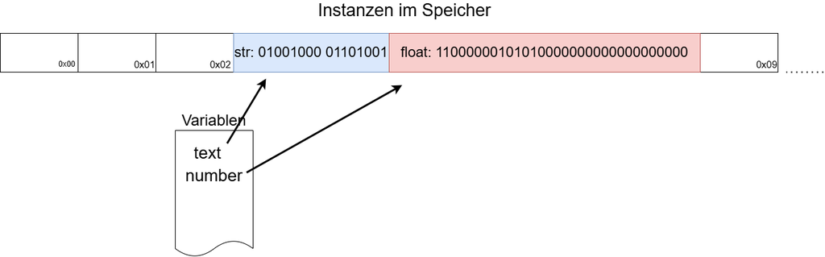

**neu**

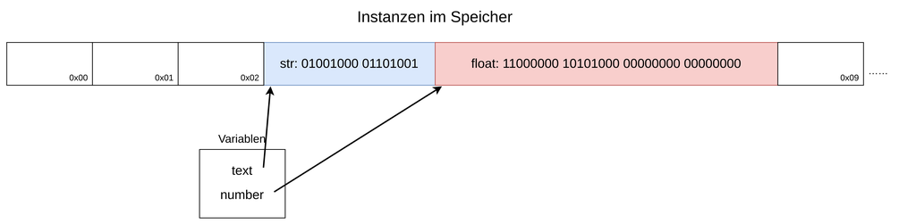

Kap 8**oop-uml-class.png**

Nur einheitlicher Stil (alle UML-Bilder jetzt in derselben Schrift wie die übrigen Abbildungen).

**bisher**

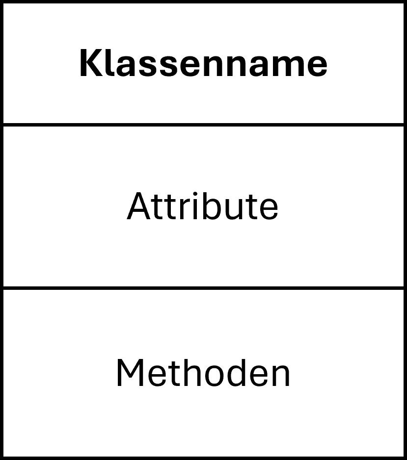

**neu**

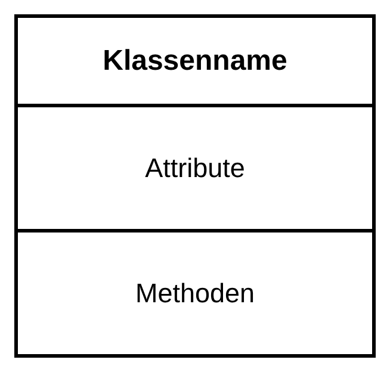

Kap 8**oop-uml-animal-class.png**

Nur einheitlicher Stil.

**bisher**

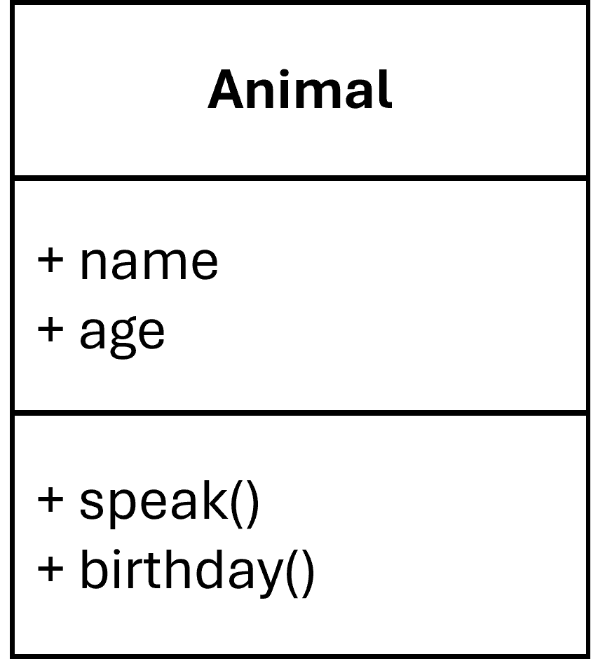

**neu**

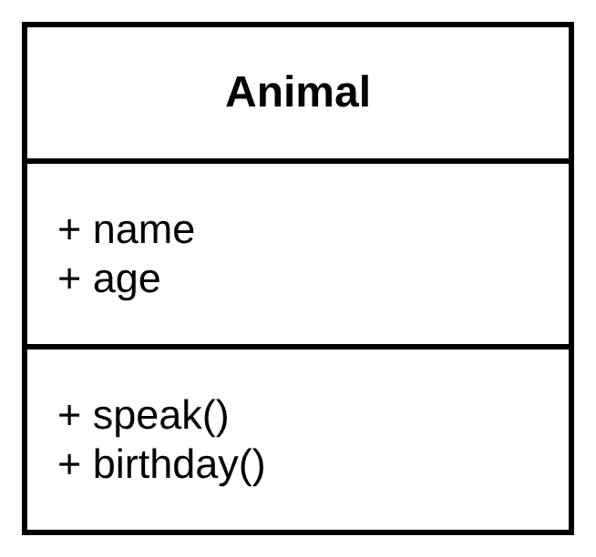

Kap 8**oop-uml-inheritance-dog-animal.png**

**Vererbungspfeil korrigiert:** nicht ausgefüllte Dreiecksspitze (UML-Generalisierung). Textvorschlag: „durch einen Pfeil mit nicht ausgefüllter Dreiecksspitze, der von der abgeleiteten Klasse zur Basisklasse zeigt“.

**bisher**

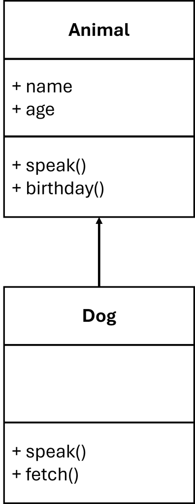

**neu**

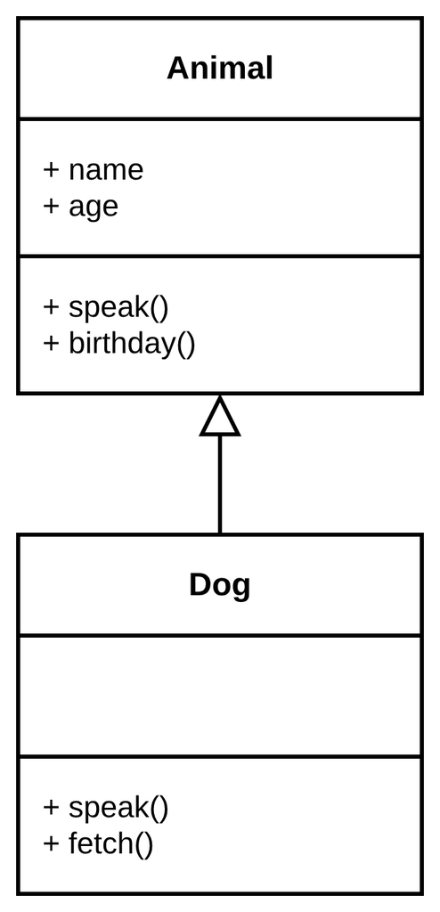

Kap 8**oop-uml-association.png**

Nur einheitlicher Stil.

**bisher**

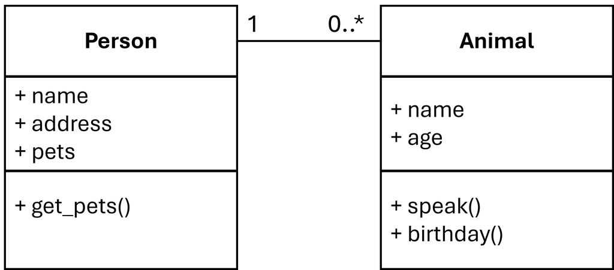

**neu**

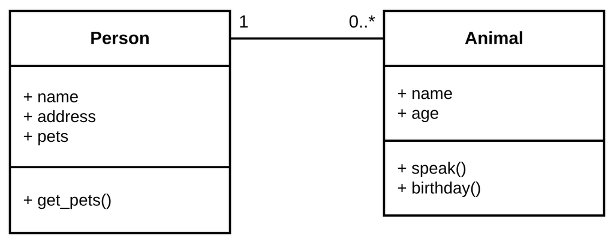

Kap 8**oop-uml-library.png**

**Vererbungspfeil korrigiert** (ein gemeinsames hohles Dreieck für Book und Magazine).

**bisher**

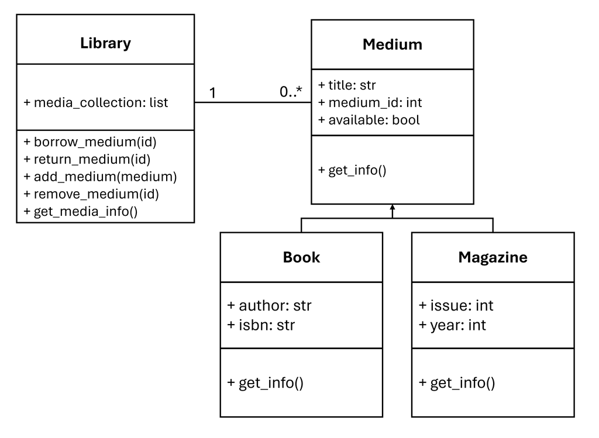

**neu**

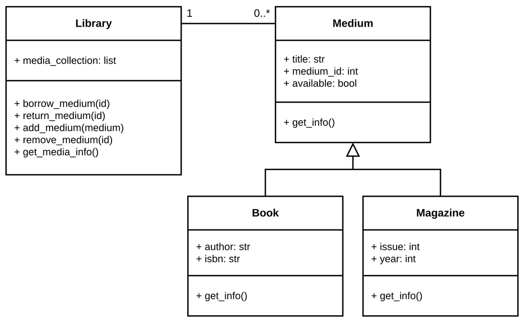

Kap 8**oop-uml-abstract.png**

**Vererbungspfeil korrigiert**; abstrakte Methoden von Shape kursiv (UML-Konvention).

**bisher**

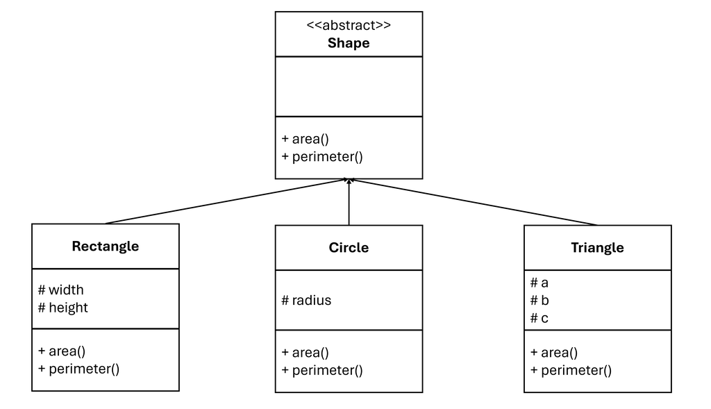

**neu**

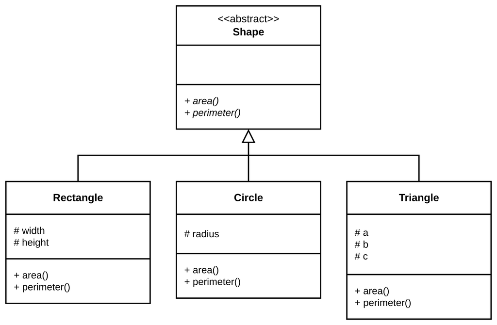